# Introducción al análisis exploratorio

El estándar científico para contestar preguntas o tomar decisiones es uno que se basa en el análisis de datos: para contestar preguntas o tomar decisiones es necesario, en primer lugar, reunir todos los datos disponibles que puedan contener o sugerir alguna guía para entender mejor la pregunta o la decisión a la que nos enfrentamos. Esta recopilación de datos -que pueden ser cualitativos, cuantitativos, o una mezcla de los dos debe entonces ser analizada para extraer información relevante para nuestro problema.

Aquí nos interesan las técnicas cuantitativas: cómo recolectar, organizar, entender, interpretar y extraer información de colecciones de datos predominantemente numéricos. Todas estas tareas son partes del análisis de datos, cuyo proceso podría resumirse con el siguiente diagrama:

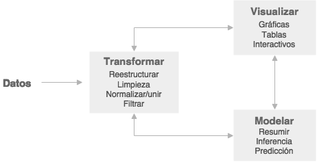

En este curso nos concentramos en los pasos transformar y visualizar, que son la parte central del análisis exploratorio de datos, sin embargo, también tocaremos el aspecto de modelar, que también juega un papel importante en el análisis exploratorio.

También es importante la forma en que nos movemos dentro de estos procesos en el análisis de datos. En palabras de Cleveland, *las herramientas son importantes*. En el proceso de análisis buscaremos seguir los siguientes principios.

1. **Reproducibilidad**. Debe ser posible reproducir el análisis en todos sus pasos, en cualquier momento.
2. **Claridad**. Los pasos del análisis deben estar documentados apropiadamente, de manera que las decisiones importantes puedan ser entendidas y explicadas claramente.

Estos dos principios generalmente implican que debemos trabajar escribiendo código, más que usando interfaces gráficas de *point and click*. Esto permite crear programas reproducibles que son fácilmente documentados, y tiene otras consecuencias positivas como la facilidad de comunicación (compartir código), la posibilidad de trabajar con versiones que documenten la historia del desarrollo, respaldos fáciles del trabajo, e incluso el uso de lenguajes de programación más flexibles que integren nuestro trabajo en procesos de producción de reportes o monitoreo.

### Ejemplo: rendimiento de campos de cebada

Comenzaremos con un ejemplo tomado de Cleveland (1994), en esta sección buscamos mostrar: primero una parte del proceso de análisis y descubrimiento característico del análisis exploratorio. El segundo objetivo del ejemplo es ilustrar los principios de *reproducibilidad* y *claridad* descritos arriba.

Comenzamos formulando una pregunta que nos interese contestar con estos datos: *¿Como varía el rendimiento a lo largo de sitios y variedades de cebada de año a año?*.

Leemos los datos. Supongamos que los datos están contenidos en dos tablas, una para 1931 y otra para 1932.

```r
# Si deseas seguir estos ejercicios en R necesitarás comenzar instalando
# algunos paquetes, para instalar los paquetes de esta clase corre la siguiente
# instrucción (esto se hace únicamente una vez)
# install.packages(c("ggplot2", "tidyr", "dplyr", "readr"))
library(dplyr)
library(tidyr)
library(readr)
library(ggplot2)

barley_1931 <- read_csv("data/barley_1931.csv")
barley_1932 <- read_csv("data/barley_1932.csv")
```

La tabla de 1931 se ve como sigue:

```r
barley_1931
```

```
Source: local data frame [10 x 7]

            variety Grand Rapids Duluth University Farm Morris Crookston
1          Svansota        29.67  25.70           35.13  25.77     40.47
2           No. 462        24.93  28.10           36.60  30.37     48.57
3         Manchuria        32.97  28.97           27.00  27.43     39.93
4           No. 475        19.70  33.07           24.67  22.60     44.10
5            Velvet        23.03  26.30           39.90  26.13     41.33
6          Peatland        34.70  32.00           32.77  29.87     41.60
7           Glabron        29.13  29.67           43.07  28.77     38.13
8           No. 457        32.17  33.60           43.27  28.70     45.67
9  Wisconsin No. 38        34.47  31.60           39.30  29.47     49.87
10            Trebi        29.77  33.93           36.57  43.77     46.93
Variables not shown: Waseca (dbl)
```

La tabla de 1932 es análoga.

Limpiamos los datos. Necesitamos unir las dos tablas para trabajar más facilmente. También nos conviene cambiar la estructura de estas tablas y agregar una etiqueta de año.

```r
barley_1931_long <- gather(barley_1931, site, yield, -variety)
barley_1931_long$year <- 1931
barley_1932_long <- gather(barley_1932, site, yield, -variety)
barley_1932_long$year <- 1932
```

La restructura de los datos resulta en una tabla donde las mediciones están en una sola columna y agregamos un identificador de sitio:

```r
barley_1931_long
```

```
Source: local data frame [60 x 4]

            variety         site yield year
1          Svansota Grand Rapids 29.67 1931
2           No. 462 Grand Rapids 24.93 1931
3         Manchuria Grand Rapids 32.97 1931
4           No. 475 Grand Rapids 19.70 1931
5            Velvet Grand Rapids 23.03 1931
6          Peatland Grand Rapids 34.70 1931
7           Glabron Grand Rapids 29.13 1931
8           No. 457 Grand Rapids 32.17 1931
9  Wisconsin No. 38 Grand Rapids 34.47 1931
10            Trebi Grand Rapids 29.77 1931
..              ...          ...   ...  ...
```

Ahora pegamos las dos bases.

```r
barley_tot <- rbind(barley_1931_long, barley_1932_long)
barley_tot
```

```
Source: local data frame [120 x 4]

            variety         site yield year
1          Svansota Grand Rapids 29.67 1931
2           No. 462 Grand Rapids 24.93 1931
3         Manchuria Grand Rapids 32.97 1931
4           No. 475 Grand Rapids 19.70 1931
5            Velvet Grand Rapids 23.03 1931
6          Peatland Grand Rapids 34.70 1931
7           Glabron Grand Rapids 29.13 1931
8           No. 457 Grand Rapids 32.17 1931
9  Wisconsin No. 38 Grand Rapids 34.47 1931
10            Trebi Grand Rapids 29.77 1931
..              ...          ...   ...  ...
```

Comenzamos con una solución sencilla. Graficamos para comparar los rendimientos.

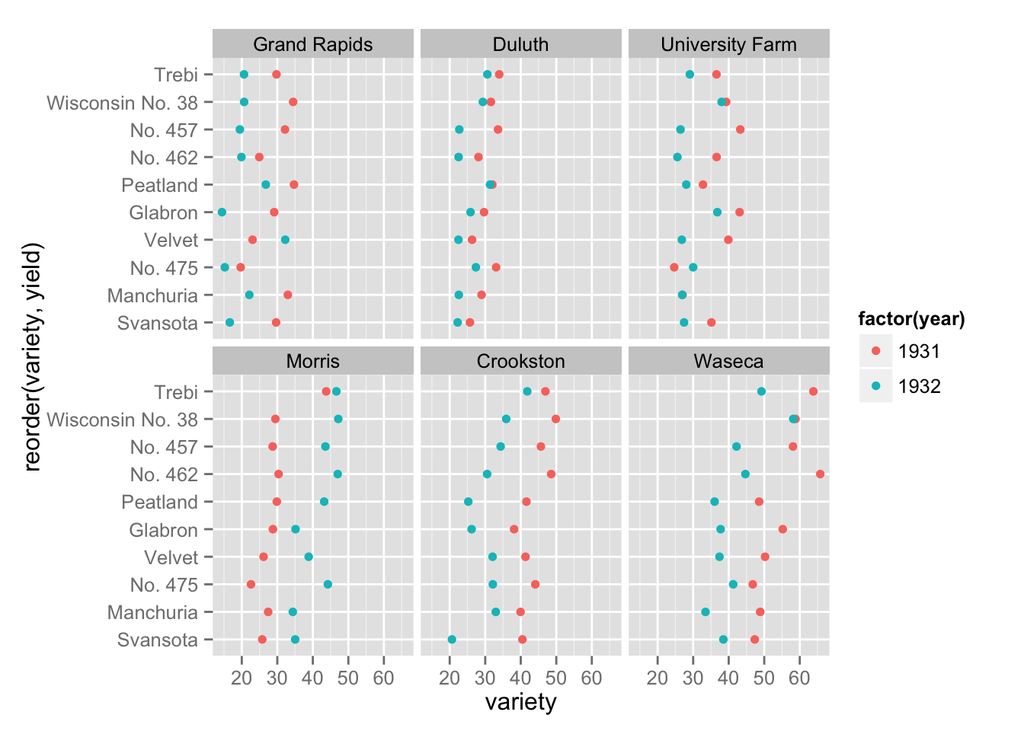

```r
ggplot(barley_tot, aes(x = reorder(variety, yield), y = yield,
  color = factor(year))) +
  facet_wrap(~site) +
  geom_point() +
  coord_flip() +
  ylab("variety")
```

Notamos que en general 1931 tuvo rendimientos más altos que 1932 y que los sitios varían en cuanto a su rendimiento (por ejemplo Duluth tiene rendimientos menores a Waseca).

Exploramos otras opciones. Primero consideramos la diferencia de 1931 a 1932, que se puede analizar más fácilmente considerando las diferencias dentro de cada sitio y para cada variedad.

```r
barley_year <- spread(barley_tot, year, yield)
barley_year
```

```
Source: local data frame [60 x 4]

     variety            site  1931  1932
1    Glabron    Grand Rapids 29.13 14.43
2    Glabron          Duluth 29.67 25.87
3    Glabron University Farm 43.07 36.80
4    Glabron          Morris 28.77 35.13
5    Glabron       Crookston 38.13 26.17
6    Glabron          Waseca 55.20 37.73
7  Manchuria    Grand Rapids 32.97 22.13
8  Manchuria          Duluth 28.97 22.57
9  Manchuria University Farm 27.00 26.90
10 Manchuria          Morris 27.43 34.37
..       ...             ...   ...   ...
```

```r
barley_year$year_diff <- barley_year$`1932` - barley_year$`1931`

barley_diff <- select(barley_year, variety, site, year_diff)
# Podemos analizar la tabla rápidamente
spread(barley_diff, site, year_diff)
```

```
Source: local data frame [10 x 7]

            variety Grand Rapids   Duluth University Farm Morris Crookston
1           Glabron      -14.700  -3.8000          -6.267  6.367   -11.967
2         Manchuria      -10.833  -6.4000          -0.100  6.933    -6.967
3           No. 457      -12.700 -10.9000         -16.833 14.833   -11.333
4           No. 462       -5.033  -5.6000         -11.033 16.633   -18.033
5           No. 475       -4.467  -5.7000           5.333 21.633   -11.967
6          Peatland       -7.933  -0.6333          -4.700 13.333   -16.367
7          Svansota      -13.033  -3.4667          -7.700  9.267   -19.833
8             Trebi       -9.133  -3.3333          -7.500  2.867    -5.100
9            Velvet        9.200  -3.8333         -13.100 12.700    -9.267
10 Wisconsin No. 38      -13.800  -2.2667          -1.300 17.700   -13.967
Variables not shown: Waseca (dbl)
```

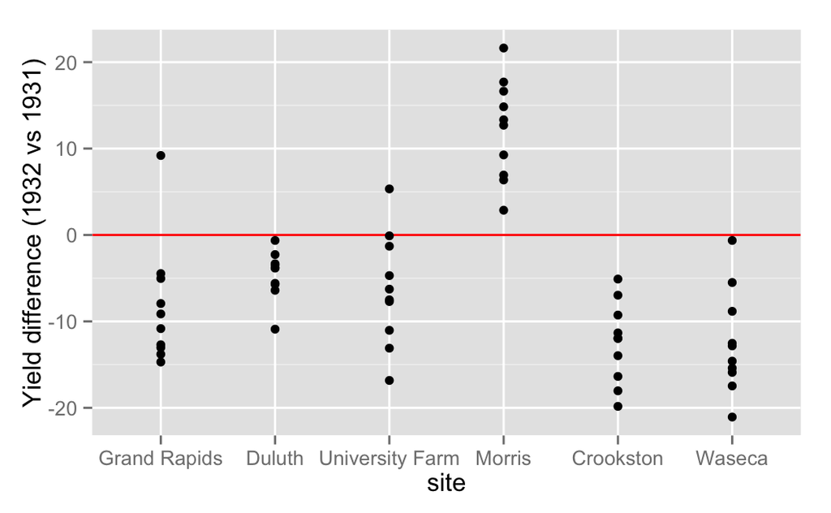

```r
ggplot(barley_diff, aes(x = site, y = year_diff)) +
  geom_hline(color = "red") +
  geom_point() +
  ylab("Yield difference (1932 vs 1931)")
```

```r
barley_morris <- filter(barley_tot, site == "Morris")
barley_morris$year <- ifelse(barley_morris$year == 1932, 1931, 1932)
barley_corrected <- rbind(subset(barley_tot, site!= "Morris"),
  barley_morris)

barley_corrected_year <- spread(barley_corrected, year, yield)
barley_corrected_year
```

```
Source: local data frame [60 x 4]

     variety            site  1931  1932
1    Glabron    Grand Rapids 29.13 14.43
2    Glabron          Duluth 29.67 25.87
3    Glabron University Farm 43.07 36.80
4    Glabron          Morris 35.13 28.77
5    Glabron       Crookston 38.13 26.17
6    Glabron          Waseca 55.20 37.73
7  Manchuria    Grand Rapids 32.97 22.13
8  Manchuria          Duluth 28.97 22.57
9  Manchuria University Farm 27.00 26.90
10 Manchuria          Morris 34.37 27.43
..       ...             ...   ...   ...
```

```r
barley_corrected_year$year_diff <- barley_corrected_year$`1932` -
  barley_corrected_year$`1931`

barley_corrected_diff <- select(barley_corrected_year, variety, site, year_diff)
# Podemos analizar la tabla rápidamente
spread(barley_corrected_diff, site, year_diff)
```

```
Source: local data frame [10 x 7]

            variety Grand Rapids   Duluth University Farm  Morris
1           Glabron      -14.700  -3.8000          -6.267  -6.367
2         Manchuria      -10.833  -6.4000          -0.100  -6.933
3           No. 457      -12.700 -10.9000         -16.833 -14.833
4           No. 462       -5.033  -5.6000         -11.033 -16.633
5           No. 475       -4.467  -5.7000           5.333 -21.633
6          Peatland       -7.933  -0.6333          -4.700 -13.333
7          Svansota      -13.033  -3.4667          -7.700  -9.267
8             Trebi       -9.133  -3.3333          -7.500  -2.867
9            Velvet        9.200  -3.8333         -13.100 -12.700
10 Wisconsin No. 38      -13.800  -2.2667          -1.300 -17.700
Variables not shown: Crookston (dbl), Waseca (dbl)
```

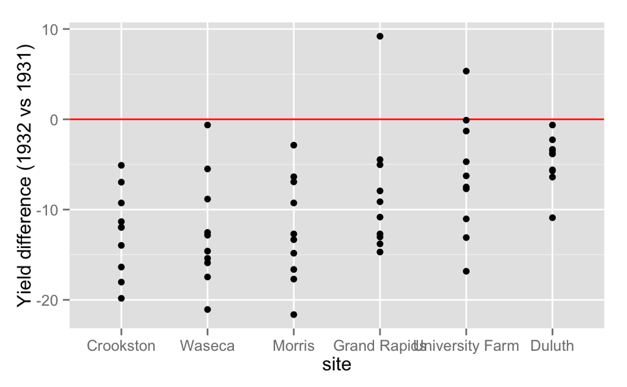

```r
ggplot(barley_corrected_diff, aes(x = reorder(site, year_diff), y = year_diff)) +
  geom_hline(color = "red") +
  geom_point() +
  ylab("Yield difference (1932 vs 1931)") +
  xlab("site")
```

```r
spread(barley_corrected_diff, site, year_diff)
```

[output not shown]

Si nos interesan las variedades, podemos resumir la diferencia en cada año a lo largo de los distintos sitios. En la siguiente tabla mostramos la media entre años en cada sitio, junto con la desviación estándar de las diferencias en cada sitio.

```r
barley_sites <- group_by(barley_corrected_year, site)
barley_sites_mean <- summarise(barley_sites,
  mean_site = round(mean(year_diff)),
  sd_site = round(sd(year_diff))
  )
arrange(barley_sites_mean, mean_site, sd_site)
```

```
Source: local data frame [6 x 3]

             site mean_site sd_site
1       Crookston       -12       5
2          Morris       -12       6
3          Waseca       -12       6
4    Grand Rapids        -8       7
5 University Farm        -6       7
6          Duluth        -5       3
```

y si agrupamos también los sitios:

```r
mean(barley_corrected_year$year_diff)
```

```
[1] -9.39
```

```r
sd(barley_corrected_year$year_diff)
```

```
[1] 6.305
```

Podemos hacer un resumen simple: en cada sitio, *ignorando las variedades*, la diferencia entre 1932 y 1931 es en promedio de $\mu=-9$ bushels por acre, con una desviación estándar de $\sigma=6$ bushels por acre. Más aún, dentro de cada sitio estas diferencias tienen aproximadamente una distribución $N(\mu,\sigma)$. ¿Esta es una buena manera de describir la diferencia de años en los datos? Veremos que la respuesta a esta pregunta depende de cuál sea el objetivo de estas descripciones. Por el momento exploremos un ejemplo más simple.

### Ejemplo: estaturas de hombres y mujeres

Los datos *singer* (paquete *lattice* de R) consisten en registros de la estatura en pulgadas de cantantes de la Sociedad de Coro de Nueva York. ¿Cómo podemos describit estos datos?

Comenzamos calculando la media y desviación estándar.

```r
singer_gender <- read_csv("data/singer_gender.csv")
singer_gender
```

```
Source: local data frame [235 x 2]

   gender height
1  Female  162.6
2  Female  157.5
3  Female  167.6
4  Female  165.1
5  Female  152.4
6  Female  154.9
7  Female  165.1
8  Female  167.6
9  Female  165.1
10 Female  160.0
..    ...    ...
```

```r
mean(singer_gender$height)
```

```
[1] 170.9
```

```r
sd(singer_gender$height)
```

```
[1] 9.715
```

Y hacemos una gráfica:

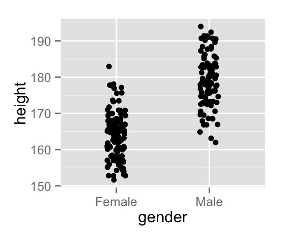

```r
ggplot(singer_gender, aes(x = gender, y = height)) +
  geom_jitter(position = position_jitter(width = 0.1, height = 1))
```

Supongamos que quisiéramos describir de manera simple los datos: independiente de si se trata de un hombre o una mujer, la estatura es una medición que se distribuye aproximadamente normal con media 171 cm y desviación estándar 10 cm. ¿Es razonable esta descripción?

Una manera de probar que tan buena es una descripción es considerar que es lo que veríamos si el modelo es el que acabamos de considerar. Para esto haremos 19 simulaciones bajo el modelo $N(\mu,\sigma)$, y comparamos las simulaciones con los datos observados. ¿Captura este modelo las características importantes observadas?

```r
library(nullabor)

singer_null <- lineup(null_dist('height', dist = 'normal',
  params = list(mean = 171, sd = 10)), n = 20, singer_gender)
```

```
decrypt("OlCE bQTQ Aw GWPATAWw J")
```

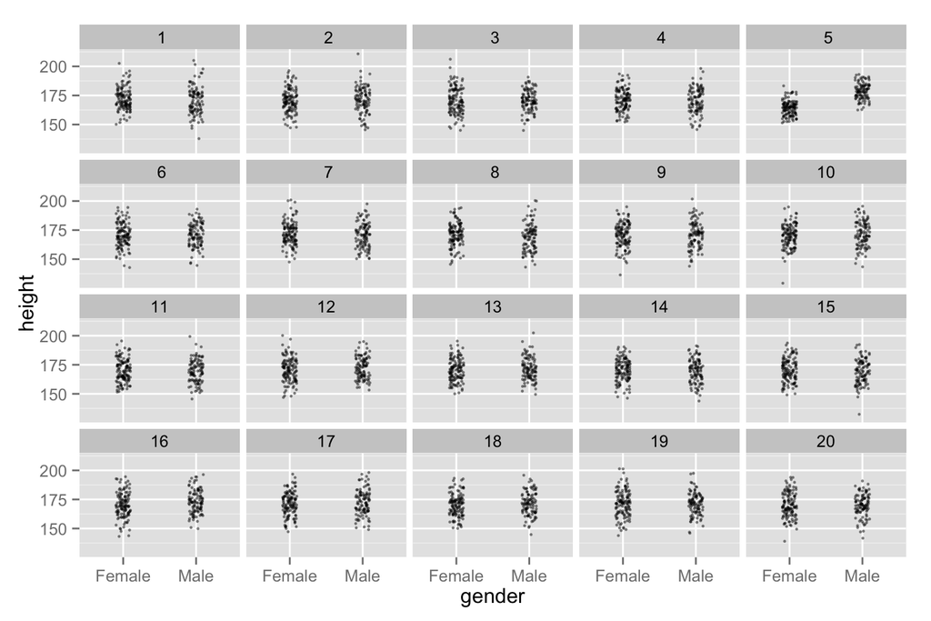

```r
ggplot(singer_null, aes(x = gender, y = height)) +
  facet_wrap(~ .sample) +
  geom_jitter(position = position_jitter(width = 0.1, height = 1),
    size = 0.8, alpha = 0.5)
```

Podemos concluir que el modelo no captura las características importantes observadas pues podemos distinguir facilmente los datos de las simulaciones, la razón es que, en general, los hombres son más altos que las mujeres, y hay menos dispersión dentro de cada uno de esos grupos. Podemos intentar una descripción un poco más compleja, si calculamos la media y desviación estandar de cada grupo obtenemos:

```r
summarise(group_by(singer_gender, gender),
  mean_height = mean(height),
  sd_height = sd(height),
  num_obs = n())
```

```
Source: local data frame [2 x 4]

  gender mean_height sd_height num_obs
1 Female       164.4     6.331     128
2   Male       178.7     6.920     107
```

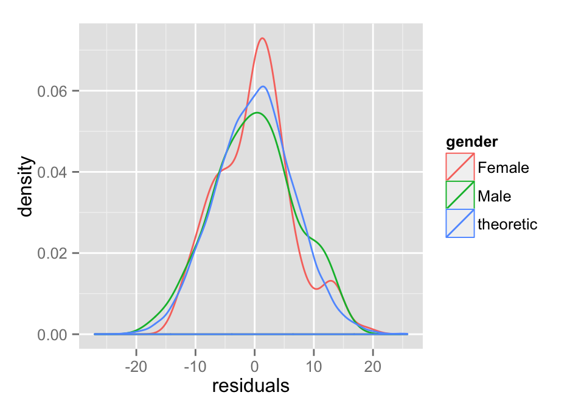

```r
singer_residuals <- mutate(group_by(singer_gender, gender),
  residuals = height - mean(height))
theoretic_residuals <- data.frame(gender = "theoretic",
  residuals = rnorm(10000, 0, 6.6))
residuals <- rbind(select(singer_residuals, gender, residuals),
  theoretic_residuals)

ggplot(residuals, aes(x = residuals, color = gender)) +
  geom_density(adjust = 1)
```

Más adelante estudiaremos variaciones de estas gráficas y herramientas con el fin de juzgar que tan similares son. Por el momento nótese que a grandes razgos las distribuciones son similares y nuestro modelo da una buena descripción de los aspectos importantes de estos datos.

### Resumen

1. **Transformar**. Hicimos varias reestructuraciones de los datos (con una especie de transposición que estudiaremos más adelante). También fue necesario generar nuevos datos a partir de los existentes haciendo cálculos y creando nuevas variables (diferencia entre años).
2. **Visualizar**. Usamos gráficas para revelar estructura en los datos. En el caso de la cebada vimos que con la herramienta correcta es fácil encontrar inconsistencias grandes en los datos.
3. **Transformar**. Corregimos los datos y repetimos los dos pasos anteriores.
4. **Transformar**. Produjimos tablas resumen de los datos.
5. **Modelar**. Usamos un modelo simple para describir un aspecto del comportamiento de los datos.
6. **Visualizar**. Produjimos visualizaciones para juzgar que tan apropiado resultó nuestro modelo para describir la diferencia entre años.

### Referencias

- William S. Cleveland. [Visualizing Data](http://www.stat.purdue.edu/~wsc/visualizing.html), 1994.
- Hadley Wickham, Dianne Cook, Heike Hofmann, y Andreas Buja, “[Graphical Inference for Infovis](http://stat.wharton.upenn.edu/~buja/PAPERS/Wickham-Cook-Hofmann-Buja-IEEE-TransVizCompGraphics_2010-Graphical%20Inference%20for%20Infovis.pdf)”, 2010.